# Bellabeat Case Study

Kristen

2024-04-15

# **Details**

- Analyze smart device usage data in order to gain insight into how consumers use non-Bellabeat smart devices
  - What are some trends in smart device usage?
  - How could these trends apply to Bellabeat customers?
  - How could these trends help influence Bellabeat marketing strategy?
- Use public data that explores smart device users’ daily habits The FitBit Fitness Tracker Data

### Deliverables:

- **A clear summary of the business task:**
  - Apply insights from non-Bellabeat smart device usage to Bellabeat products to inform marketing strategy
- **A description of all data sources used**
  - [**FitBit Fitness Tracker Data**](https://www.kaggle.com/datasets/arashnic/fitbit): Contains the data from 30 eligible FitBit users (respondents) who submitted their daily tracked activities, which included physical activity, heart rate, & sleep. The data was collected from 3/12/2016 to 5/12/2016. It is in a long data format and was collected through a survey distributed by Amazon Mechanical Turk. It was posted on Zenodo & Kaggle.
- **Documentation of any cleaning or manipulation of data**

Loading Packages

```r
library(reshape2)
library(ragg)
library(tidyverse)
library(here)
library(skimr)
library(janitor)
library(ggplot2)
library(purrr)
library(dplyr)
```

Setting File Path

```r
setwd("C:/Users/krist/OneDrive/Documents/GitHub/Capstone/docs")
```

Loading Data

```r
daily_activity_1 <- read.csv("dailyActivity_merged_1.csv")
```

Reviewing Data

```r
skim_without_charts(daily_activity_1)
```

Data summary

| Name | daily_activity_1 |
| --- | --- |
| Number of rows | 457 |
| Number of columns | 15 |
| _______________________ |  |
| Column type frequency: |  |
| character | 1 |
| numeric | 14 |
| ________________________ |  |
| Group variables | None |

**Variable type: character**

| skim_variable | n_missing | complete_rate | min | max | empty | n_unique | whitespace |
| --- | --- | --- | --- | --- | --- | --- | --- |
| ActivityDate | 0 | 1 | 8 | 9 | 0 | 32 | 0 |

**Variable type: numeric**

| skim_variable | n_missing | complete_rate | mean | sd | p0 | p25 | p50 | p75 | p100 |
| --- | --- | --- | --- | --- | --- | --- | --- | --- | --- |
| Id | 0 | 1 | 4.628595e+09 | 2.293781e+09 | 1503960366 | 2.347168e+09 | 4.057193e+09 | 6.391747e+09 | 8.877689e+09 |
| TotalSteps | 0 | 1 | 6.546560e+03 | 5.398490e+03 | 0 | 1.988000e+03 | 5.986000e+03 | 1.019800e+04 | 2.849700e+04 |
| TotalDistance | 0 | 1 | 4.660000e+00 | 4.080000e+00 | 0 | 1.410000e+00 | 4.090000e+00 | 7.160000e+00 | 2.753000e+01 |
| TrackerDistance | 0 | 1 | 4.610000e+00 | 4.070000e+00 | 0 | 1.280000e+00 | 4.090000e+00 | 7.110000e+00 | 2.753000e+01 |
| LoggedActivitiesDistance | 0 | 1 | 1.800000e-01 | 8.500000e-01 | 0 | 0.000000e+00 | 0.000000e+00 | 0.000000e+00 | 6.730000e+00 |
| VeryActiveDistance | 0 | 1 | 1.180000e+00 | 2.490000e+00 | 0 | 0.000000e+00 | 0.000000e+00 | 1.310000e+00 | 2.192000e+01 |
| ModeratelyActiveDistance | 0 | 1 | 4.800000e-01 | 8.300000e-01 | 0 | 0.000000e+00 | 2.000000e-02 | 6.700000e-01 | 6.400000e+00 |
| LightActiveDistance | 0 | 1 | 2.890000e+00 | 2.240000e+00 | 0 | 8.700000e-01 | 2.930000e+00 | 4.460000e+00 | 1.251000e+01 |
| SedentaryActiveDistance | 0 | 1 | 0.000000e+00 | 1.000000e-02 | 0 | 0.000000e+00 | 0.000000e+00 | 0.000000e+00 | 1.000000e-01 |
| VeryActiveMinutes | 0 | 1 | 1.662000e+01 | 2.892000e+01 | 0 | 0.000000e+00 | 0.000000e+00 | 2.500000e+01 | 2.020000e+02 |
| FairlyActiveMinutes | 0 | 1 | 1.307000e+01 | 3.621000e+01 | 0 | 0.000000e+00 | 1.000000e+00 | 1.600000e+01 | 6.600000e+02 |
| LightlyActiveMinutes | 0 | 1 | 1.700700e+02 | 1.222100e+02 | 0 | 6.400000e+01 | 1.810000e+02 | 2.570000e+02 | 7.200000e+02 |
| SedentaryMinutes | 0 | 1 | 9.952800e+02 | 3.370200e+02 | 32 | 7.280000e+02 | 1.057000e+03 | 1.285000e+03 | 1.440000e+03 |
| Calories | 0 | 1 | 2.189450e+03 | 8.154800e+02 | 0 | 1.776000e+03 | 2.062000e+03 | 2.667000e+03 | 4.562000e+03 |

```r
glimpse(daily_activity_1)
```

```
## Rows: 457
## Columns: 15
## $ Id                       <dbl> 1503960366, 1503960366, 1503960366, 150396036…
## $ ActivityDate             <chr> "3/25/2016", "3/26/2016", "3/27/2016", "3/28/…
## $ TotalSteps               <int> 11004, 17609, 12736, 13231, 12041, 10970, 122…
## $ TotalDistance            <dbl> 7.11, 11.55, 8.53, 8.93, 7.85, 7.16, 7.86, 7.…
## $ TrackerDistance          <dbl> 7.11, 11.55, 8.53, 8.93, 7.85, 7.16, 7.86, 7.…
## $ LoggedActivitiesDistance <dbl> 0, 0, 0, 0, 0, 0, 0, 0, 0, 0, 0, 0, 0, 0, 0, …
## $ VeryActiveDistance       <dbl> 2.57, 6.92, 4.66, 3.19, 2.16, 2.36, 2.29, 3.3…
## $ ModeratelyActiveDistance <dbl> 0.46, 0.73, 0.16, 0.79, 1.09, 0.51, 0.49, 0.8…
## $ LightActiveDistance      <dbl> 4.07, 3.91, 3.71, 4.95, 4.61, 4.29, 5.04, 3.6…
## $ SedentaryActiveDistance  <dbl> 0.00, 0.00, 0.00, 0.00, 0.00, 0.00, 0.00, 0.0…
## $ VeryActiveMinutes        <int> 33, 89, 56, 39, 28, 30, 33, 47, 40, 15, 43, 3…
## $ FairlyActiveMinutes      <int> 12, 17, 5, 20, 28, 13, 12, 21, 11, 30, 18, 18…
## $ LightlyActiveMinutes     <int> 205, 274, 268, 224, 243, 223, 239, 200, 244, …
## $ SedentaryMinutes         <int> 804, 588, 605, 1080, 763, 1174, 820, 866, 636…
## $ Calories                 <int> 1819, 2154, 1944, 1932, 1886, 1820, 1889, 186…
```

```r
head(daily_activity_1)
```

```
##           Id ActivityDate TotalSteps TotalDistance TrackerDistance
## 1 1503960366    3/25/2016      11004          7.11            7.11
## 2 1503960366    3/26/2016      17609         11.55           11.55
## 3 1503960366    3/27/2016      12736          8.53            8.53
## 4 1503960366    3/28/2016      13231          8.93            8.93
## 5 1503960366    3/29/2016      12041          7.85            7.85
## 6 1503960366    3/30/2016      10970          7.16            7.16
##   LoggedActivitiesDistance VeryActiveDistance ModeratelyActiveDistance
## 1                        0               2.57                     0.46
## 2                        0               6.92                     0.73
## 3                        0               4.66                     0.16
## 4                        0               3.19                     0.79
## 5                        0               2.16                     1.09
## 6                        0               2.36                     0.51
##   LightActiveDistance SedentaryActiveDistance VeryActiveMinutes
## 1                4.07                       0                33
## 2                3.91                       0                89
## 3                3.71                       0                56
## 4                4.95                       0                39
## 5                4.61                       0                28
## 6                4.29                       0                30
##   FairlyActiveMinutes LightlyActiveMinutes SedentaryMinutes Calories
## 1                  12                  205              804     1819
## 2                  17                  274              588     2154
## 3                   5                  268              605     1944
## 4                  20                  224             1080     1932
## 5                  28                  243              763     1886
## 6                  13                  223             1174     1820
```

```r
View(daily_activity_1)
```

Converting Values

```r
daily_activity_1 <- daily_activity_1 %>%
  mutate(ActivityDate = lubridate::mdy(ActivityDate))

class(daily_activity_1$ActivityDate)
```

```
## [1] "Date"
```

Sorting

```r
daily_activity_1 <- daily_activity_1 %>%
  arrange(ActivityDate, Id)

View(daily_activity_1)
```

Determining Number of Unique Ids (there are only supposed to be 30 users)

```r
length(unique(daily_activity_1$Id))
```

```
## [1] 35
```

Downloading Other Datasets

```r
sleep_minutes_1 <- read.csv("minuteSleep_merged_1.csv")
heartrate_seconds_1 <- read.csv("heartrate_seconds_merged_1.csv")
steps_minutes_1 <- read.csv("minuteStepsNarrow_merged_1.csv")
intensities_minutes_1 <- read.csv("minuteIntensitiesNarrow_merged_1.csv")
calories_minutes_1 <- read.csv("minuteCaloriesNarrow_merged_1.csv")
```

Comparing Datasets

```r
unique(calories_minutes_1$Id)
```

```
##  [1] 1503960366 1624580081 1644430081 1844505072 1927972279 2022484408
##  [7] 2026352035 2320127002 2347167796 2873212765 2891001357 3372868164
## [13] 3977333714 4020332650 4057192912 4319703577 4445114986 4558609924
## [19] 4702921684 5553957443 5577150313 6117666160 6290855005 6391747486
## [25] 6775888955 6962181067 7007744171 7086361926 8053475328 8253242879
## [31] 8378563200 8583815059 8792009665 8877689391
```

```r
unique(intensities_minutes_1$Id)
```

```
##  [1] 1503960366 1624580081 1644430081 1844505072 1927972279 2022484408
##  [7] 2026352035 2320127002 2347167796 2873212765 2891001357 3372868164
## [13] 3977333714 4020332650 4057192912 4319703577 4445114986 4558609924
## [19] 4702921684 5553957443 5577150313 6117666160 6290855005 6391747486
## [25] 6775888955 6962181067 7007744171 7086361926 8053475328 8253242879
## [31] 8378563200 8583815059 8792009665 8877689391
```

```r
unique(sleep_minutes_1$Id) # missing some Ids
```

```
##  [1] 1503960366 1644430081 1844505072 1927972279 2022484408 2026352035
##  [7] 2347167796 3977333714 4020332650 4319703577 4445114986 4558609924
## [13] 4702921684 5553957443 5577150313 6117666160 6775888955 6962181067
## [19] 7007744171 7086361926 8053475328 8378563200 8792009665
```

```r
unique(steps_minutes_1$Id)
```

```
##  [1] 1503960366 1624580081 1644430081 1844505072 1927972279 2022484408
##  [7] 2026352035 2320127002 2347167796 2873212765 2891001357 3372868164
## [13] 3977333714 4020332650 4057192912 4319703577 4445114986 4558609924
## [19] 4702921684 5553957443 5577150313 6117666160 6290855005 6391747486
## [25] 6775888955 6962181067 7007744171 7086361926 8053475328 8253242879
## [31] 8378563200 8583815059 8792009665 8877689391
```

```r
length(unique(calories_minutes_1$ActivityMinute))
```

```
## [1] 45300
```

```r
length(unique(intensities_minutes_1$ActivityMinute))
```

```
## [1] 45300
```

```r
length(unique(sleep_minutes_1$date)) # named & formatted differently, has more values in date column
```

```
## [1] 54523
```

```r
length(unique(steps_minutes_1$ActivityMinute))
```

```
## [1] 45300
```

Combining Like Datasets

```r
combined_minutes <- cbind(calories_minutes_1, intensities_minutes_1[,3, drop=FALSE])

full_combined_minutes <- cbind(combined_minutes, steps_minutes_1[,3, drop=FALSE])
```

Separating ActivityMinute Column

```r
combined_minutes_clean_1 <- full_combined_minutes %>%
  separate(ActivityMinute, into = c('date', 'time', 'am_pm'), sep = ' ', remove = TRUE)
```

Downloading Other Datasets

```r
sleep_day_2 <- read.csv("sleepDay_merged_2.csv")
daily_activity_2 <- read.csv("dailyActivity_merged_2.csv")
```

Reviewing Datasets

```r
nrow(sleep_day_2) # 413
```

```
## [1] 413
```

```r
nrow(daily_activity_2) # 940
```

```
## [1] 940
```

```r
length(unique(sleep_day_2$Id)) # 24
```

```
## [1] 24
```

```r
length(unique(daily_activity_2$Id)) # 33
```

```
## [1] 33
```

```r
sleep_day_2 %>%
  select(TotalSleepRecords, TotalMinutesAsleep, TotalTimeInBed) %>%
  summary()
```

```
##  TotalSleepRecords TotalMinutesAsleep TotalTimeInBed
##  Min.   :1.000     Min.   : 58.0      Min.   : 61.0
##  1st Qu.:1.000     1st Qu.:361.0      1st Qu.:403.0
##  Median :1.000     Median :433.0      Median :463.0
##  Mean   :1.119     Mean   :419.5      Mean   :458.6
##  3rd Qu.:1.000     3rd Qu.:490.0      3rd Qu.:526.0
##  Max.   :3.000     Max.   :796.0      Max.   :961.0
```

```r
daily_activity_2 %>%
  select(TotalSteps, TotalDistance, SedentaryMinutes) %>%
  summary()
```

```
##    TotalSteps    TotalDistance    SedentaryMinutes
##  Min.   :    0   Min.   : 0.000   Min.   :   0.0
##  1st Qu.: 3790   1st Qu.: 2.620   1st Qu.: 729.8
##  Median : 7406   Median : 5.245   Median :1057.5
##  Mean   : 7638   Mean   : 5.490   Mean   : 991.2
##  3rd Qu.:10727   3rd Qu.: 7.713   3rd Qu.:1229.5
##  Max.   :36019   Max.   :28.030   Max.   :1440.0
```

Looking for Trends

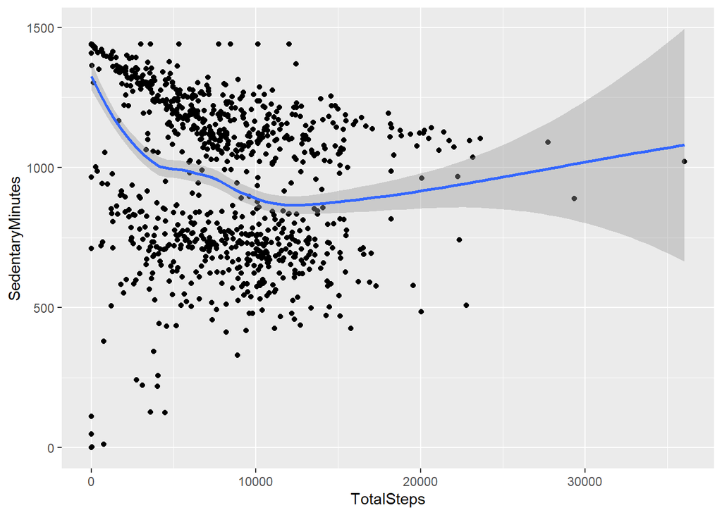

```r
ggplot(data = daily_activity_2) +
  geom_point(mapping = aes(x = TotalSteps, y = SedentaryMinutes)) +
  geom_smooth(mapping = aes(x = TotalSteps, y = SedentaryMinutes))
```

Looking for Trends

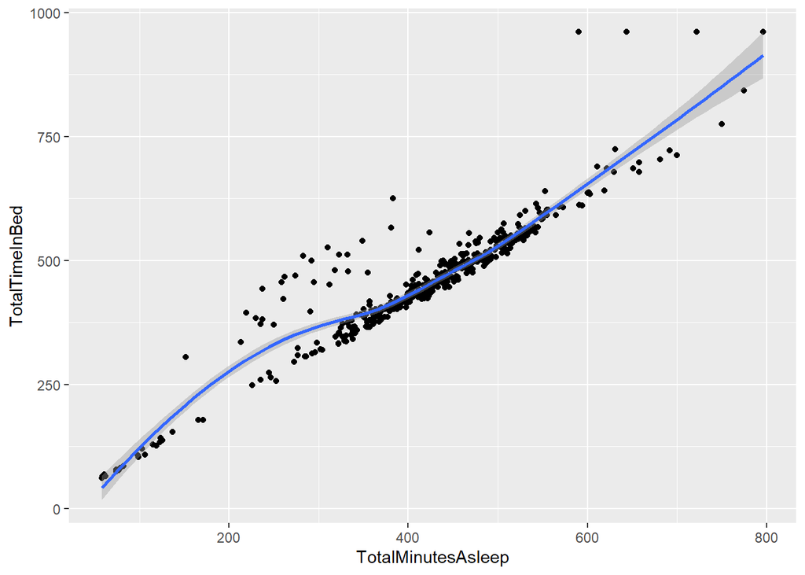

```r
ggplot(data = sleep_day_2) +
  geom_point(mapping = aes(x = TotalMinutesAsleep, y = TotalTimeInBed)) +
  geom_smooth(mapping = aes(x = TotalMinutesAsleep, y = TotalTimeInBed))
```

Separating Columns

```r
sleep_day_2_edit <- sleep_day_2 %>%
  separate(SleepDay, into = c('Date', 'Time', 'Am_Pm'), sep = ' ', remove = TRUE)

sleep_day_2_edit[-c(3, 4)]
```

Renaming Columns

```r
daily_activity_2_edit <- daily_activity_2 %>%
  rename(Date = ActivityDate)
View(daily_activity_2_edit)
```

Combining Datasets

```r
combined_sleep_activity_day <- right_join(sleep_day_2_edit, daily_activity_2_edit)
combined_sleep_activity_day[-c(3,4)]
```

Reviewing Data

```r
n_distinct(combined_sleep_activity_day$Id) # 24 w/ merge function, 33 w/ full join function
```

```
## [1] 33
```

```r
unique(sleep_day_2$Id)
```

```
##  [1] 1503960366 1644430081 1844505072 1927972279 2026352035 2320127002
##  [7] 2347167796 3977333714 4020332650 4319703577 4388161847 4445114986
## [13] 4558609924 4702921684 5553957443 5577150313 6117666160 6775888955
## [19] 6962181067 7007744171 7086361926 8053475328 8378563200 8792009665
```

```r
unique(daily_activity_2$Id)
```

```
##  [1] 1503960366 1624580081 1644430081 1844505072 1927972279 2022484408
##  [7] 2026352035 2320127002 2347167796 2873212765 3372868164 3977333714
## [13] 4020332650 4057192912 4319703577 4388161847 4445114986 4558609924
## [19] 4702921684 5553957443 5577150313 6117666160 6290855005 6775888955
## [25] 6962181067 7007744171 7086361926 8053475328 8253242879 8378563200
## [31] 8583815059 8792009665 8877689391
```

```r
nrow(daily_activity_2)
```

```
## [1] 940
```

```r
nrow(sleep_day_2)
```

```
## [1] 413
```

```r
413+940 # <- this is the max number of rows the joined data should have
```

```
## [1] 1353
```

Looking for Trends

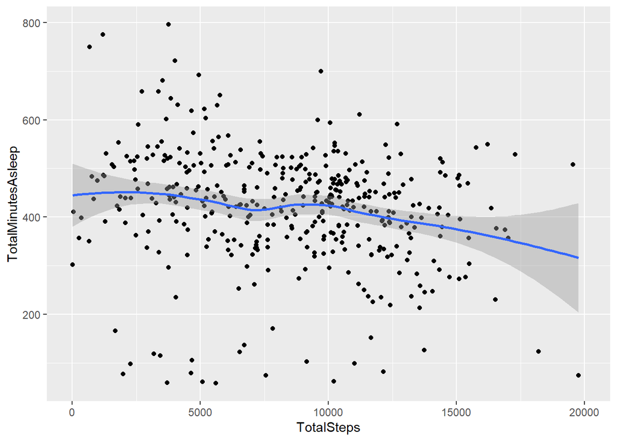

```r
ggplot(data = combined_sleep_activity_day) +
  geom_point(mapping = aes(x = TotalSteps, y = TotalMinutesAsleep)) +
  geom_smooth(mapping = aes(x = TotalSteps, y = TotalMinutesAsleep)) +
  xlim(0, 20000)
```

Looking for Trends

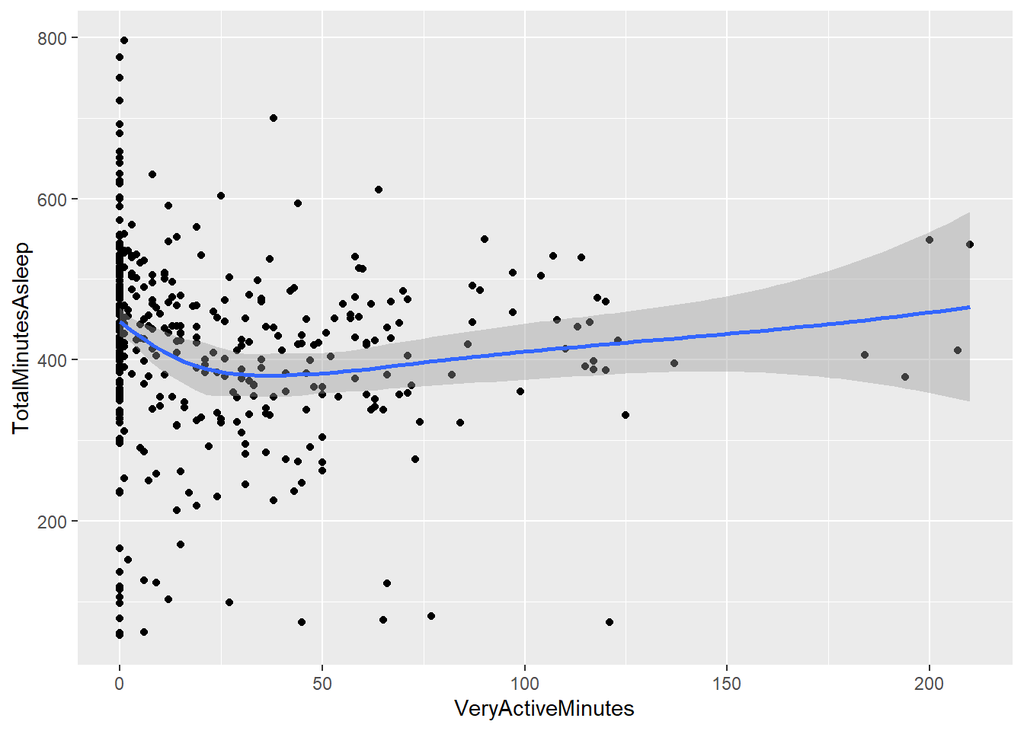

```r
ggplot(data = combined_sleep_activity_day) +
  geom_point(mapping = aes(x = VeryActiveMinutes, y = TotalMinutesAsleep)) +
  geom_smooth(mapping = aes(x = VeryActiveMinutes, y = TotalMinutesAsleep))
```

Looking for Trends

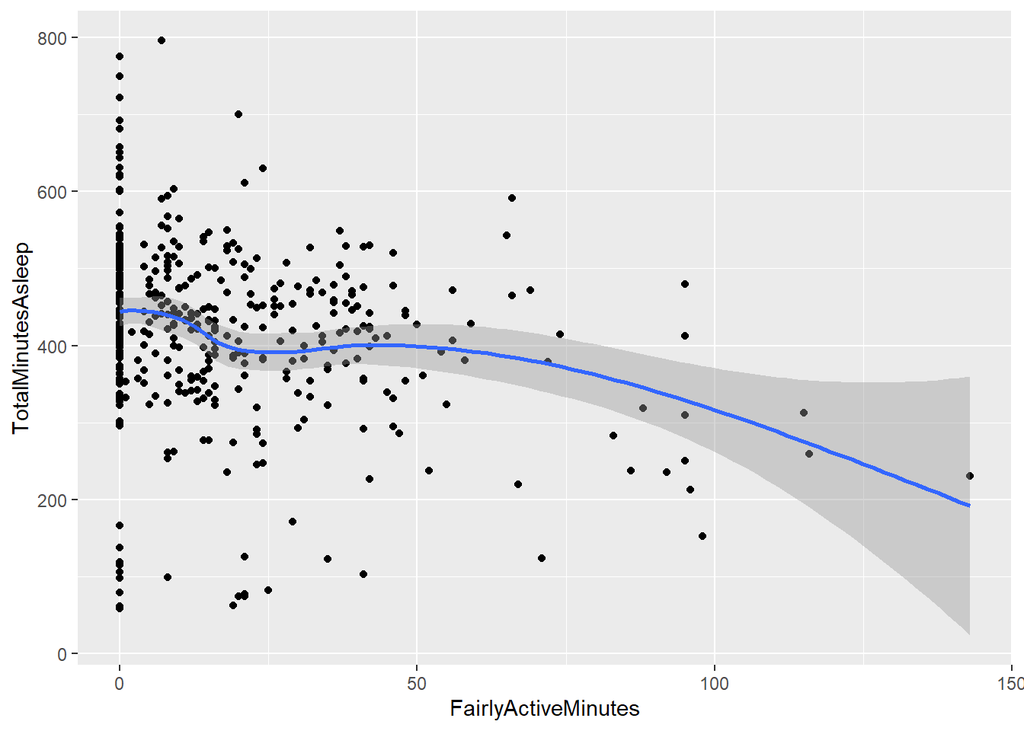

```r
ggplot(data = combined_sleep_activity_day) +
  geom_point(mapping = aes(x = FairlyActiveMinutes, y = TotalMinutesAsleep)) +
  geom_smooth(mapping = aes(x = FairlyActiveMinutes, y = TotalMinutesAsleep))
```

Looking for Trends

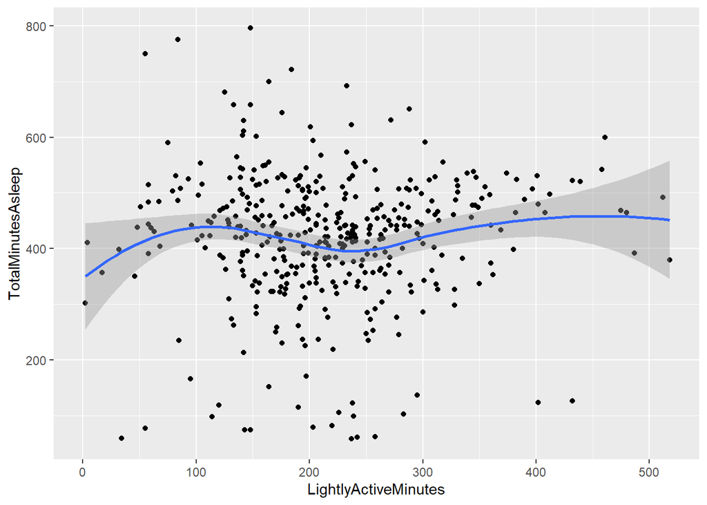

```r
ggplot(data = combined_sleep_activity_day) +
  geom_point(mapping = aes(x = LightlyActiveMinutes, y = TotalMinutesAsleep)) +
  geom_smooth(mapping = aes(x = LightlyActiveMinutes, y = TotalMinutesAsleep))
```

Looking for Trends

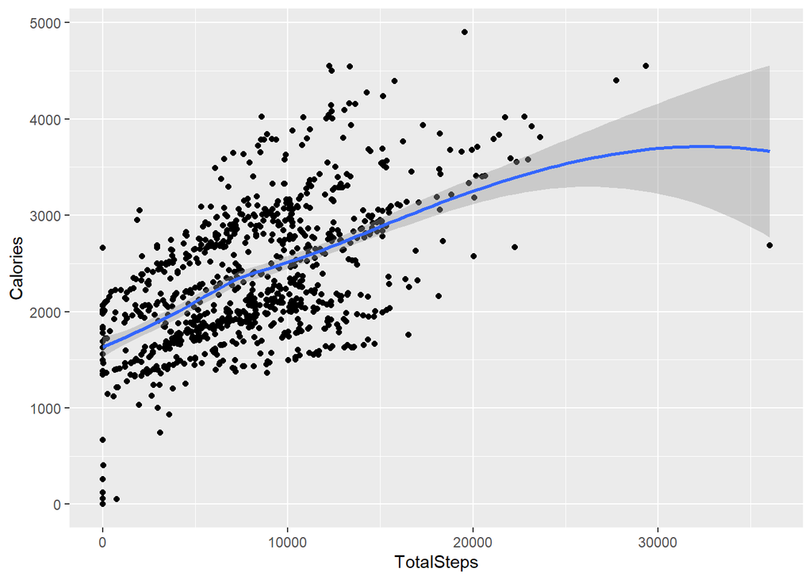

```r
ggplot(data = combined_sleep_activity_day) +
  geom_point(mapping = aes(x = TotalSteps, y = Calories)) +
  geom_smooth(mapping = aes(x = TotalSteps, y = Calories))
```

Looking for Trends

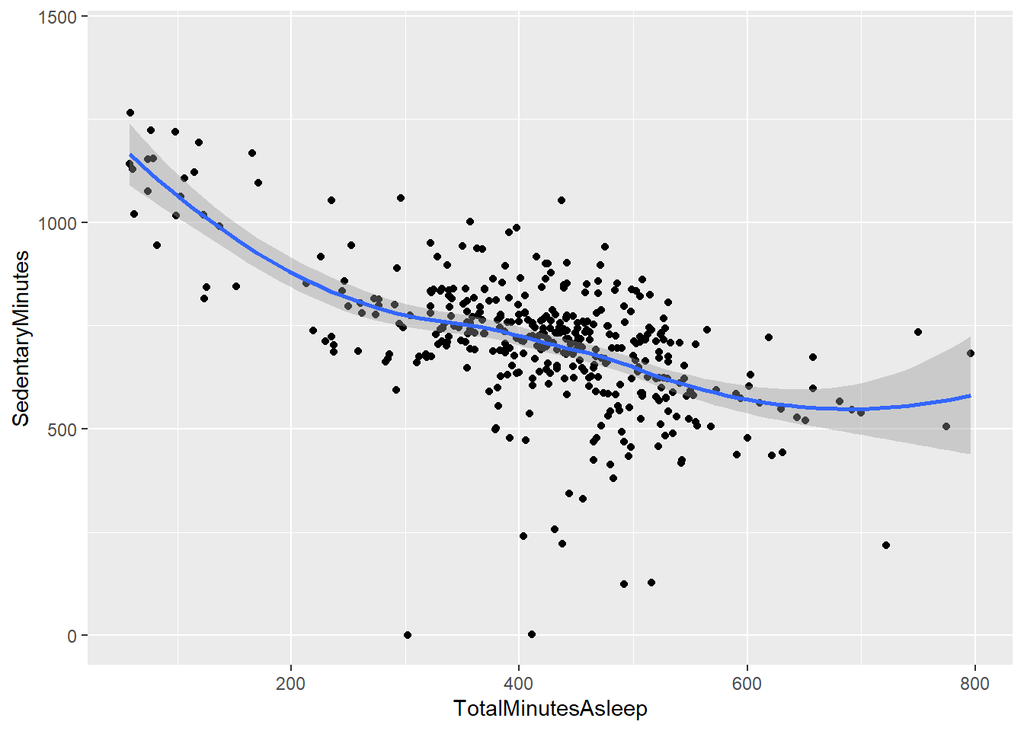

```r
ggplot(data = combined_sleep_activity_day) +
  geom_point(mapping = aes(x = TotalMinutesAsleep, y = SedentaryMinutes)) +
  geom_smooth(mapping = aes(x = TotalMinutesAsleep, y = SedentaryMinutes))
```

Melting Data

```r
sleep_activity_melt <- melt(combined_sleep_activity_day, na.rm = FALSE, c("LightlyActiveMinutes", "VeryActiveMinutes"), id = c("Calories"))
```

Renaming Columns

```r
sleep_activity_melt_edit <- sleep_activity_melt %>%
  rename(ActivityLevel = variable, Minutes = value)
```

Filtering Data

```r
sleep_activity_melt_edit_2 <- filter(sleep_activity_melt_edit, Calories > 0, Minutes > 0)
```

Looking for Trends

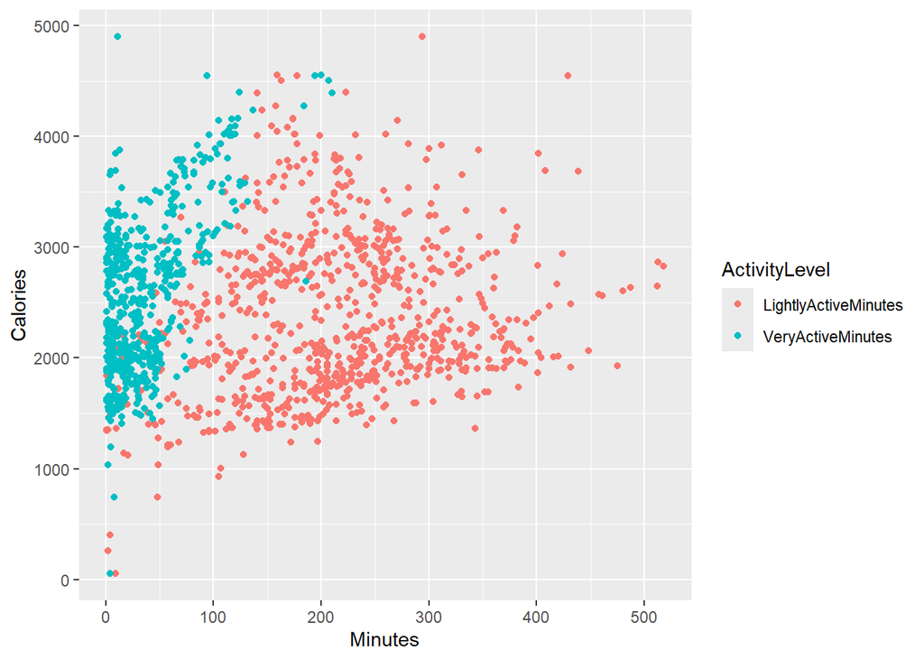

```r
ggplot(data = sleep_activity_melt_edit_2) +
  geom_point(mapping = aes(x = Minutes, y = Calories, color = ActivityLevel))
```

Melting Data

```r
sleep_activity_melt_3 <- melt(combined_sleep_activity_day, na.rm = FALSE, c("LightlyActiveMinutes", "FairlyActiveMinutes", "VeryActiveMinutes"), id = c("Calories"))
```

Renaming columns

```r
sleep_activity_melt_edit_3 <- sleep_activity_melt_3 %>%
  rename(ActivityLevel = variable, Minutes = value)
```

Filtering Data

```r
sleep_activity_melt_edit_4 <- filter(sleep_activity_melt_edit_3, Calories > 0, Minutes > 0)
```

Looking for Trends

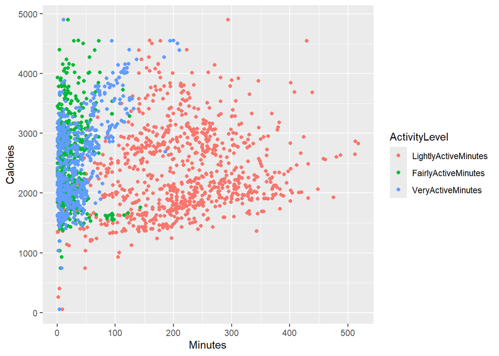

```r
ggplot(data = sleep_activity_melt_edit_4) +
  geom_point(mapping = aes(x = Minutes, y = Calories, color = ActivityLevel))
```

Looking for Trends

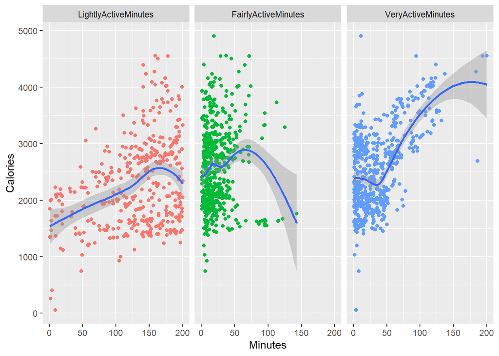

```r
ggplot(data = sleep_activity_melt_edit_4) +
  geom_point(mapping = aes(x = Minutes, y = Calories, color = ActivityLevel)) +
  geom_smooth(mapping = aes(x = Minutes, y = Calories)) +
  facet_wrap(~ActivityLevel) +
  xlim(0, 200) +
  guides(color = FALSE)
```

Filtering Data

```r
daily_activity_2_edit2 <- filter(daily_activity_2_edit, Calories > 0, LightlyActiveMinutes > 0)
```

Looking for Trends

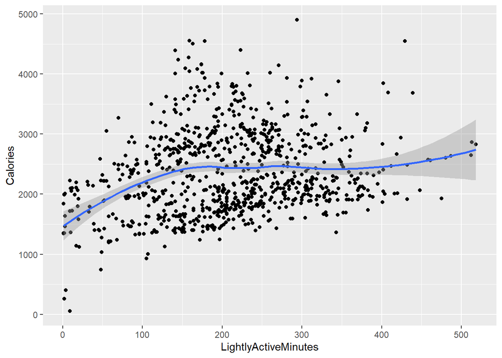

```r
ggplot(data = daily_activity_2_edit2) +
  geom_point(mapping = aes(x = LightlyActiveMinutes, y = Calories)) +
  geom_smooth(mapping = aes(x = LightlyActiveMinutes, y = Calories))
```

Looking for Trends

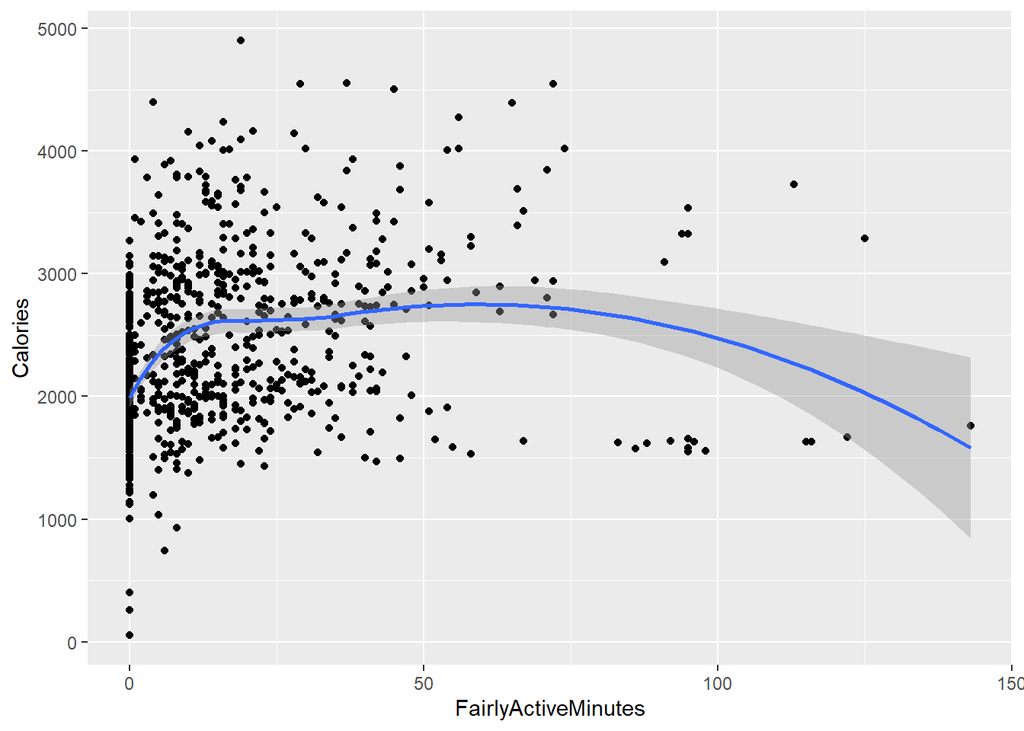

```r
ggplot(data = daily_activity_2_edit2) +
  geom_point(mapping = aes(x = FairlyActiveMinutes, y = Calories)) +
  geom_smooth(mapping = aes(x = FairlyActiveMinutes, y = Calories))
```

Looking for Trends

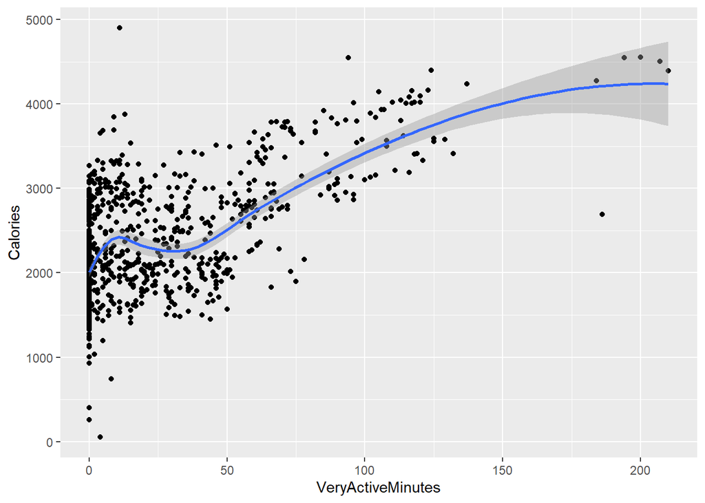

```r
ggplot(data = daily_activity_2_edit2) +
  geom_point(mapping = aes(x = VeryActiveMinutes, y = Calories)) +
  geom_smooth(mapping = aes(x = VeryActiveMinutes, y = Calories))
```

- **A summary of your analysis**  
  **Trial & Error**  
  I began my analysis by looking at the Daily Activity data from the first half of the study. I reviewed the data and cleaned it. Nothing jumped out at me so I moved on to other datasets, particularly the ones recording different variables by the minute. However, I noticed the heart rate data was by seconds. I had the idea to find the average of each minute so I could combine it with the other datasets that were by the minute. I ended up abandoning this idea because it would be incredibly time consuming. I combined the datasets that were by the minute & tried to plot the data to look for trends. This was unsuccessful.  
  **Trends**  
  I moved on to other datasets, specifically the daily sleep & daily activity datasets from the second half of the study. I reviewed the data and began looking for trends. This was more successful. I found that for up to ~10,000 steps there is a negative correlation between sedentary minutes & total steps (more sedentary minutes means less total steps). I also discovered that not a lot of the users are extremely active (extremely active being 15,000+ steps and less 500 sedentary minutes). There are more moderate, average activity users. Once I saw some initial trends I combined the data using an outer join (I first manipulated the data so it would match and combine successfully). I looked for trends in the combined data.I was interested in if total steps had any correlation with total minutes asleep (it did not) and if very active minutes had any correlation with total minutes asleep (it did not). I did however notice a positive correlation between total steps and calories burned (the more steps you take the more calories you burn). I also saw a negative correlation between sedentary minutes and total minutes asleep (the more sedentary minutes the less time asleep).  
  I melted the combined data so that all activity levels would be in one column and could be plotted as facets to compare their relationship to calories burned. Through the plots of the melted table I was able to determine that there was a positive correlation between lightly active minutes and calories burned up to about 150 lightly active minutes. There was no correlation between fairly active minutes and calories burned. There was a positive correlation between very active minutes and calories burned from about 50 minutes to 150 minutes.
- **Supporting visuals & key findings**